# Project 2

George Bridges and Marcus Lee 6/27/2021

# Tuesday Report

## Introduction section

This data set contains the daily count of rental bikes between the years of 2011 and 2012 in the Capital bike share system with the corresponding weather and seasonal information.

The purpose of our analysis is to try to predict the number of users using predictive models which will include linear regressions, and different tree models. See the modeling section to know more about which models we have used.

## Data

```r
data_days <- read_csv("day.csv")
```

After looking at the `day.csv`, the variables not selected for Marcus analysis are listed below:

- `instant`
- `dteday`
- `casual` I will be using the `cnt` variable
- `registered` I will be using the `cnt` variable
- `yr`
- `mnth`
- `holiday`
- `workingday`
- `weathersit`

George decided to include weathersit, but exclude season. I also included ‘holiday’ and ‘workingday’ I will be using the ‘cnt’ variable in place of ‘casual’ or ‘registered.’

```r
data_days2 <- data_days %>% select(-c(instant, dteday, casual, registered, yr, mnth, holiday, workingday, weathersit))
```

```r
data_days22 <- data_days %>% select(-c(instant, dteday, casual, registered, yr, mnth, season))
```

```r
data_days3 <- data_days2 %>% mutate(weekday = case_when(weekday==1 ~ "Monday",
                                                        weekday==2 ~ "Tuesday",
                                                        weekday==3 ~ "Wednesday",
                                                        weekday==4 ~ "Thursday",
                                                        weekday==5 ~ "Friday",
                                                        weekday==6 ~ "Saturday",
                                                        weekday==0 ~ "Sunday"))
```

```r
data_days33 <- data_days22 %>% mutate(weekday = case_when(weekday==1 ~ "Monday",
                                                        weekday==2 ~ "Tuesday",
                                                        weekday==3 ~ "Wednesday",
                                                        weekday==4 ~ "Thursday",
                                                        weekday==5 ~ "Friday",
                                                        weekday==6 ~ "Saturday",
                                                        weekday==0 ~ "Sunday"))
```

The code below will filter by the day.

```r
# The code that is in comment is for the automation later
data_by_day <- data_days3 %>% filter(weekday == params$day)
#data_by_day <- data_days3 %>% filter(weekday=="Monday")
```

```r
#data_by_day22 <- data_days33 %>% filter(weekday=="Monday")
data_by_day22 <- data_days33 %>% filter(weekday == params$day)
```

## Training and Testing set

I will be randomly sample from the data in order to form a training(use 70% of the data) and test set(use 30% of the data). I set a seed to make the work reproducible.

```r
set.seed(123)
train <- sample(1:nrow(data_by_day), size=nrow(data_by_day)*0.7)
test <- dplyr::setdiff(1:nrow(data_by_day), train)

daydataTrain <- data_by_day[train, ]
daydataTest <- data_by_day[test, ]
```

```r
train2 <- sample(1:nrow(data_by_day22), size=nrow(data_by_day22)*0.7)
test2 <- dplyr::setdiff(1:nrow(data_by_day22), train2)

daydataTrain2 <- data_by_day22[train2, ]
daydataTest2 <- data_by_day22[test2, ]
```

## Summary Statistics

```r
grouped_mean.sd_on_some_variables <- daydataTrain %>% group_by(season) %>% summarise(
  n=n(),
  avg_temp = round(mean(temp),2),
  avg_atemp = round(mean(atemp),2),
  avg_hum = round(mean(hum),2),
  avg_windspeed = round(mean(windspeed),2),
  avg_cnt = round(mean(cnt),2),
  sd_temp = round(sd(temp),2),
  sd_atemp = round(sd(atemp),2),
  sd_hum = round(sd(hum),2),
  sd_windspeed = round(sd(windspeed),2),
  sd_cnt = round(sd(cnt),2)
) %>% rename('Average temperature'=avg_temp,
             'Average feeling temperature'=avg_atemp,
             'Average humidity' = avg_hum,
             'Average Windspeed' = avg_windspeed,
             'Average count of total rental bikes'= avg_cnt,
             'Standard deviation of temperature' = sd_temp,
             'Standard deviation of feeling temperature' = sd_atemp,
             'Standard deviation of humidity' = sd_hum,
             'Standard deviation of windspeed' = sd_windspeed,
             'Standard deviation of count of total rental bikes' = sd_cnt)
```

```r
grouped_meansd <- daydataTrain2 %>% group_by(weathersit) %>% summarise(
  n=n(),
  avg_temp = round(mean(temp),2),
  avg_atemp = round(mean(atemp),2),
  avg_hum = round(mean(hum),2),
  avg_windspeed = round(mean(windspeed),2),
  avg_cnt = round(mean(cnt),2),
  avg_hol = round(mean(holiday),2),
  avg_work = round(mean(workingday),2),
  sd_temp = round(sd(temp),2),
  sd_atemp = round(sd(atemp),2),
  sd_hum = round(sd(hum),2),
  sd_windspeed = round(sd(windspeed),2),
  sd_cnt = round(sd(cnt),2)

) %>% rename('Average temperature'=avg_temp,
             'Average feeling temperature'=avg_atemp,
             'Average humidity' = avg_hum,
             'Average Windspeed' = avg_windspeed,
             'Average count of total rental bikes'= avg_cnt,
             'Proportion of days that are holidays' = avg_hol,
             'Proportion of days that are working days' = avg_work,
             'Standard deviation of temperature' = sd_temp,
             'Standard deviation of feeling temperature' = sd_atemp,
             'Standard deviation of humidity' = sd_hum,
             'Standard deviation of windspeed' = sd_windspeed,
             'Standard deviation of count of total rental bikes' = sd_cnt)
```

```r
kable(grouped_mean.sd_on_some_variables, caption= "Summary Statistics on some of the variables based off of the different seasons")
```

| season | n | Average temperature | Average feeling temperature | Average humidity | Average Windspeed | Average count of total rental bikes | Standard deviation of temperature | Standard deviation of feeling temperature | Standard deviation of humidity | Standard deviation of windspeed | Standard deviation of count of total rental bikes |
| --- | --- | --- | --- | --- | --- | --- | --- | --- | --- | --- | --- |
| 1 | 13 | 0.28 | 0.28 | 0.57 | 0.23 | 2635.69 | 0.11 | 0.10 | 0.14 | 0.09 | 1463.97 |
| 2 | 19 | 0.55 | 0.52 | 0.61 | 0.23 | 4475.89 | 0.14 | 0.12 | 0.16 | 0.08 | 1433.79 |
| 3 | 23 | 0.70 | 0.65 | 0.64 | 0.18 | 5691.22 | 0.08 | 0.07 | 0.14 | 0.08 | 1427.20 |
| 4 | 17 | 0.45 | 0.44 | 0.70 | 0.16 | 5075.53 | 0.10 | 0.09 | 0.12 | 0.06 | 1702.29 |

Summary Statistics on some of the variables based off of the different seasons

```r
kable(grouped_meansd, caption= "Summary Statistics on some of the variables based off of the different weather situations")
```

| weathersit | n | Average temperature | Average feeling temperature | Average humidity | Average Windspeed | Average count of total rental bikes | Proportion of days that are holidays | Proportion of days that are working days | Standard deviation of temperature | Standard deviation of feeling temperature | Standard deviation of humidity | Standard deviation of windspeed | Standard deviation of count of total rental bikes |
| --- | --- | --- | --- | --- | --- | --- | --- | --- | --- | --- | --- | --- | --- |
| 1 | 43 | 0.53 | 0.50 | 0.56 | 0.20 | 4788.40 | 0.00 | 1.00 | 0.20 | 0.18 | 0.12 | 0.07 | 1771.98 |
| 2 | 28 | 0.45 | 0.43 | 0.74 | 0.20 | 3735.14 | 0.04 | 0.96 | 0.15 | 0.13 | 0.09 | 0.09 | 1749.85 |
| 3 | 1 | 0.54 | 0.52 | 0.89 | 0.34 | 2710.00 | 0.00 | 1.00 | NA | NA | NA | NA | NA |

Summary Statistics on some of the variables based off of the different weather situations

Below we see a contingency table that displays holidays and working days. As one would expect, no day is both a working day and a holiday

```r
table(daydataTrain2$holiday, daydataTrain2$workingday)
```

```
##
##      0  1
##   0  0 71
##   1  1  0
```

Here below are multiple plots based off of some of the variables in the `daydataTrain`. For each of these plots, I was trying to get a feeling like if the weather is much colder, then there would be a lesser amount of total rental bikes including both the `casual` and `registered` variable.

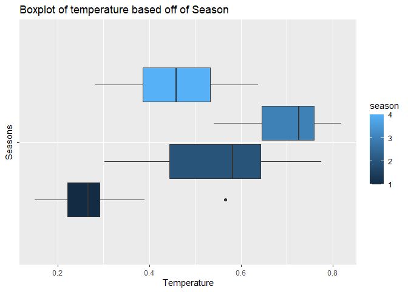

```r
# Box plot seasons temperature
ggplot(daydataTrain, aes(group=season, temp, y="", fill=season))+geom_boxplot()+ggtitle("Boxplot of temperature based off of Season")+ylab("Seasons")+xlab("Temperature")
```

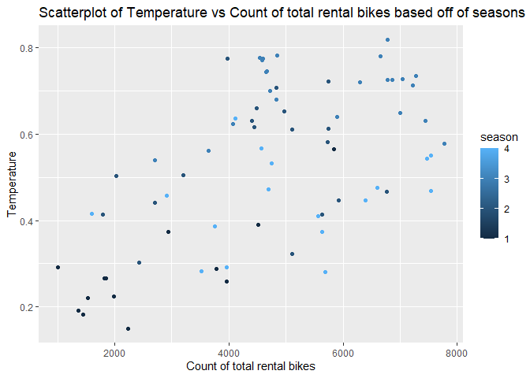

```r
# Scatterplot cnt vs temp based off of season

ggplot(daydataTrain, aes(x=cnt, y=temp, color=season))+geom_point()+labs(x="Count of total rental bikes", y="Temperature", title="Scatterplot of Temperature vs Count of total rental bikes based off of seasons")
```

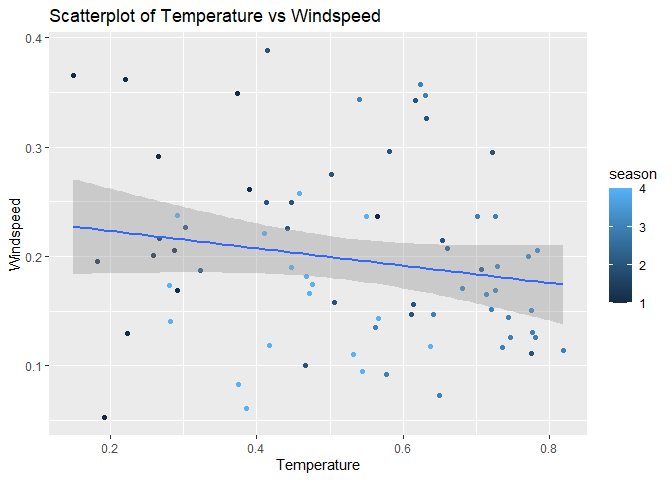

```r
# Scatterplot of Temperature vs Windspeed
ggplot(daydataTrain, aes(x=temp,y=windspeed, color=season))+geom_point()+geom_smooth(aes(temp,windspeed),method=lm)+labs(x="Temperature", y="Windspeed", title="Scatterplot of Temperature vs Windspeed")
```

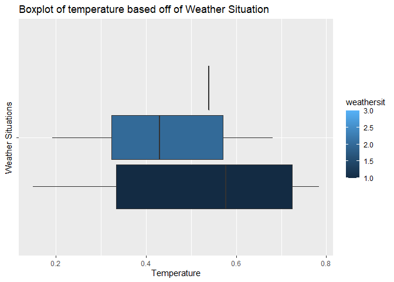

```r
#boxplot temperature versus weather situation
ggplot(daydataTrain2, aes(group=weathersit, temp, y="", fill=weathersit))+geom_boxplot()+ggtitle("Boxplot of temperature based off of Weather Situation") +ylab("Weather Situations")+xlab("Temperature")
```

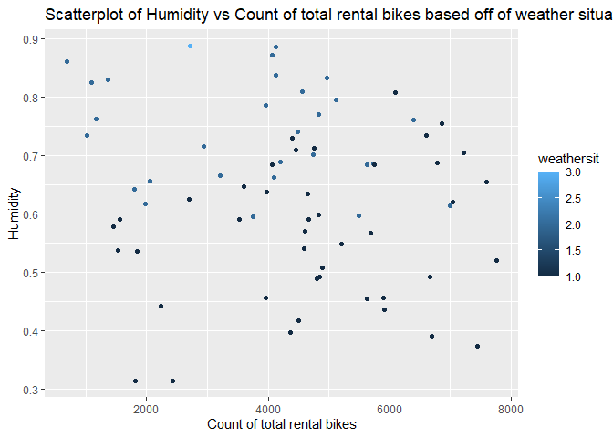

```r
#scatterplot cnt vs humidity based off of weather situation
ggplot(daydataTrain2, aes(x=cnt, y=hum, color=weathersit))+geom_point()+labs(x="Count of total rental bikes", y="Humidity", title="Scatterplot of Humidity vs Count of total rental bikes based off of weather situations")
```

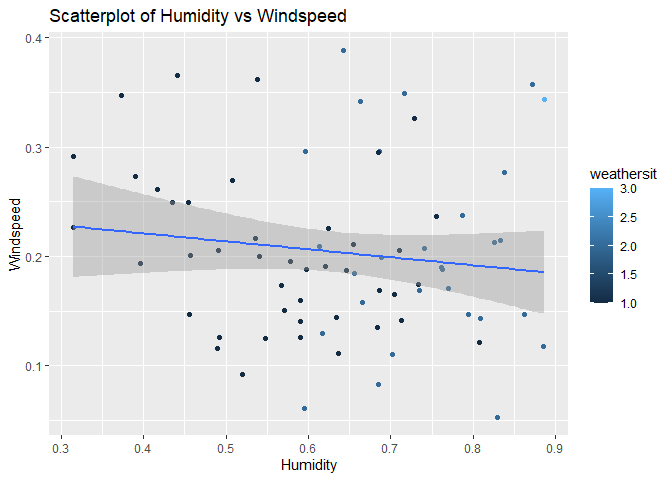

```r
# Scatterplot of Humidity vs Windspeed
ggplot(daydataTrain2, aes(x=hum,y=windspeed, color=weathersit))+geom_point()+geom_smooth(aes(hum,windspeed),method=lm)+labs(x="Humidity", y="Windspeed", title="Scatterplot of Humidity vs Windspeed")
```

For the 1st scatterplot, we can inspect the relationship between the count of total rental bikes against temperature based off of different seasons. If we were to make separate regression fit lines, we would expect each of the fit lines to have different slopes because we grouped by season. So if the total rental bikes increases, we can assume that the temperature increases as well.

For the 2nd scatterplot, we can inspect the relationship between the temperature and the windspeed based off of the different seasons. Based off of the plot, as the temperature increases, windspeed may decrease.

For the 3rd scatterplot, we can see the relationship between total rental bikes against humidity based on weather situation. I would expect higher humidity to mean less rented bikes.

For the 4th scatterplot, we can see the relationship between windspeed and humidity in the different weather situations. I would not expect to see a strong relationship here for any of the weather situations, though it is possible that dryer air is lighter and therefore might blow a little faster but that is pure speculation on George’s part.

## Modeling

A linear regression model attempts to model the relationship between variables by fitting a linear equation to observed data. The most common method of fitting is that of least squares, in which the line is ‘drawn’ based on the line that will minimize the sum of the squares of the vertical deviations of each data point from the line, also called the residuals of each data point. If a single explanatory variable is used, the model is called simple linear regression, if multiple explanatory variables are used then it is called multiple linear regression.

```r
# Did not include the categorical variables
model_1 <- lm(cnt ~ temp+atemp+hum+windspeed, data=daydataTrain)
summary(model_1)
```

```
##
## Call:
## lm(formula = cnt ~ temp + atemp + hum + windspeed, data = daydataTrain)
##
## Residuals:
##     Min      1Q  Median      3Q     Max
## -2539.6 -1066.6   -60.3   956.1  2584.0
##
## Coefficients:
##             Estimate Std. Error t value Pr(>|t|)
## (Intercept)     3367       1122   3.002  0.00377 **
## temp          -18220      12032  -1.514  0.13466
## atemp          27591      13719   2.011  0.04834 *
## hum            -3894       1177  -3.307  0.00152 **
## windspeed      -2332       2220  -1.050  0.29733
## ---
## Signif. codes:  0 '***' 0.001 '**' 0.01 '*' 0.05 '.' 0.1 ' ' 1
##
## Residual standard error: 1376 on 67 degrees of freedom
## Multiple R-squared:  0.4606, Adjusted R-squared:  0.4284
## F-statistic:  14.3 on 4 and 67 DF,  p-value: 1.716e-08
```

```r
anova(model_1)
```

```
## Analysis of Variance Table
##
## Response: cnt
##           Df    Sum Sq  Mean Sq F value   Pr(>F)
## temp       1  77892181 77892181 41.1368 1.67e-08 ***
## atemp      1   7189407  7189407  3.7969  0.05554 .
## hum        1  21160595 21160595 11.1754  0.00136 **
## windspeed  1   2089007  2089007  1.1033  0.29733
## Residuals 67 126863983  1893492
## ---
## Signif. codes:  0 '***' 0.001 '**' 0.01 '*' 0.05 '.' 0.1 ' ' 1
```

```r
VIF(model_1)
```

```
##       temp      atemp        hum  windspeed
## 181.751752 185.166816   1.090954   1.225797
```

```r
#included weathersit and temp, the two variables I thought would be most predictive
model_2 <- lm(cnt ~ weathersit+temp, data=daydataTrain2)
summary(model_2)
```

```
##
## Call:
## lm(formula = cnt ~ weathersit + temp, data = daydataTrain2)
##
## Residuals:
##     Min      1Q  Median      3Q     Max
## -2386.3 -1078.3  -144.1   867.6  2747.9
##
## Coefficients:
##             Estimate Std. Error t value Pr(>|t|)
## (Intercept)   2140.5      677.1   3.161  0.00234 **
## weathersit    -643.4      304.5  -2.113  0.03821 *
## temp          6285.4      857.2   7.333 3.31e-10 ***
## ---
## Signif. codes:  0 '***' 0.001 '**' 0.01 '*' 0.05 '.' 0.1 ' ' 1
##
## Residual standard error: 1322 on 69 degrees of freedom
## Multiple R-squared:  0.4892, Adjusted R-squared:  0.4744
## F-statistic: 33.05 on 2 and 69 DF,  p-value: 8.586e-11
```

```r
anova(model_2)
```

```
## Analysis of Variance Table
##
## Response: cnt
##            Df    Sum Sq  Mean Sq F value    Pr(>F)
## weathersit  1  21538493 21538493  12.324 0.0007925 ***
## temp        1  93963124 93963124  53.766  3.31e-10 ***
## Residuals  69 120586803  1747635
## ---
## Signif. codes:  0 '***' 0.001 '**' 0.01 '*' 0.05 '.' 0.1 ' ' 1
```

```r
VIF(model_2)
```

```
## weathersit       temp
##   1.034473   1.034473
```

The idea of fitting a random forest model is that you take bootstrap samples, and fit a tree to each of those using a random subset of the predictors. Finally, you average the results. I used the ‘rf’ method, the training data set, and repeated cross validation to fit the model, I then test it on the test data.

```r
trctrl <- trainControl(method = "repeatedcv", number = 4, repeats = 3)
#create random forest model
raFore <- train(cnt ~ temp + atemp + hum + windspeed,
                method = "rf",
                trControl = trctrl,
                data = daydataTrain2,
                preProcess = c("center", "scale"))
#predict for our cnt variable and compare to test data
raFore_pred <- predict(raFore, newdata = daydataTest2)

raFore_pred2 <- table(raFore_pred, daydataTest2$cnt)
misclass2 <- 1 - (sum(diag(raFore_pred2))/sum(raFore_pred2))
misclass2
```

```
## [1] 0.9375
```

To predict the total amount of rental bikes, I used the ensemble model using the `gbm` method and I tuned on the training set(Using repeated cross validation). Also, I evaluated on the test data set for figuring out the misclassification rate and I would use this to make a better model.

```r
trctrl <- trainControl(method = "repeatedcv", number=10, repeats=5)
#create a boosted model tree
boostree <- train(cnt ~ temp+atemp+hum+windspeed,
               method = 'gbm',
               trControl=trctrl,
               data=daydataTrain,
               preProcess=c("center", "scale"),
               verbose = FALSE)
#predict the values for our cnt variable and compare it to our testing data.
boostree_pred <- predict(boostree, newdata=daydataTest)
#a frequency of how many of each response there is.
boostree_pred2 <- table(boostree_pred, daydataTest$cnt)
misclass <- 1-(sum(diag(boostree_pred2))/sum(boostree_pred2))
misclass
```

```
## [1] 0.90625
```

## Comparison

```r
prediction1 <- predict(model_1, newdata = daydataTest)
prediction2 <- predict(model_2, newdata = daydataTest2)
prediction3 <- predict(raFore, newdata = daydataTest2)
prediction4 <- predict(boostree, newdata = daydataTest)
rmse1 <- postResample(prediction1, obs = daydataTest$cnt)
rmse2 <- postResample(prediction2, obs = daydataTest2$cnt)
rmse3 <- postResample(prediction3, obs = daydataTest2$cnt)
rmse4 <- postResample(prediction4, obs = daydataTest$cnt)

kable(data.frame(rmse1[1], rmse2[1], rmse3[1], rmse4[1]))
```

|  | rmse1.1. | rmse2.1. | rmse3.1. | rmse4.1. |
| --- | --- | --- | --- | --- |
| RMSE | 1212.397 | 1424.627 | 1332.236 | 1510.658 |